# 13 - ANOVA

Chun Yu, Ko

2022-11-25

[Home page](https://seimwiwa.github.io/scu_master_degree_program_data_science_statistical_analysis/)

# 1 Key point

# 2 Single Factor Analysis of variance 單因子變異數分析

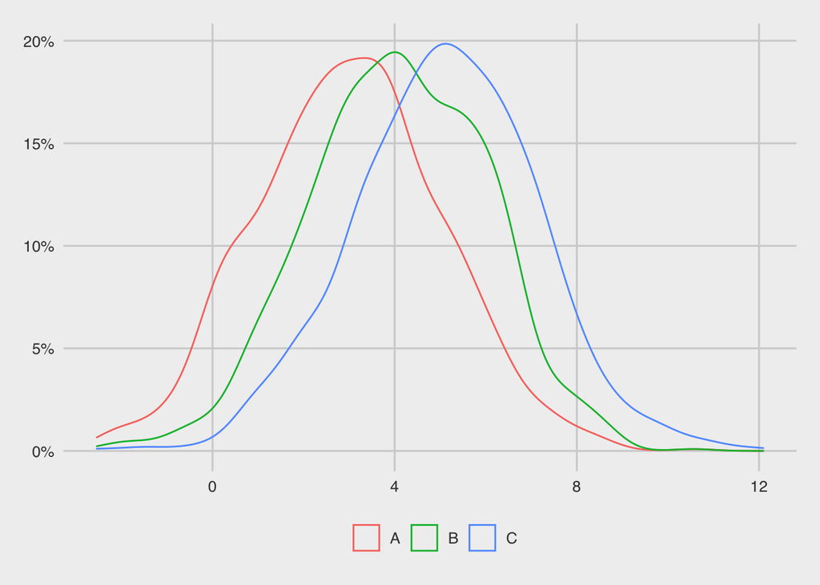

## 2.1 ANOVA 的思想

當有三個或以上的組別時，想要知道這幾個組別的數值長相是不是一致

故可以看：組別跟組別之間的差異大不大 vs 不管組別的所有數值的差異大不大

也就是在看：組間變異 (Between-group variance) vs 組內變異 (Within-group variance)

## 2.2 F 檢定統計量

為了比較組間、組內差異，所以把兩個平均變異相除成為 F 值（F 是費雪 Fishers）

$F=\frac{平均組間變異 MSB}{平均組變異異 MSE}=\frac{(\frac{組間變異 SSB}{c-1})}{(\frac{組內變異 SSE}{n-c})}$

當平均組間變異 > 平均組內差異，則 $F > 1$，代表不同組別間的差異比組內的差異大，就是不同組別比較離散，也就是不同組別可有沒差異

當平均組間變異 < 平均組內差異，則 $F < 1$，代表不同組別間的差異比組內的差異小，就是不同組別比較集中，也就是不同組別可能沒差異

總變異 Total $SST = SSB + SSE = \sum_{j=1}^{c}\sum_{i=1}^{n_j}(y_{ij}-\overline{y})^2$

組間變異 Treatment $SSB = \sum_{j=1}^{c}n_j(\overline{y}_j - \overline{y})^2$，就是各組平均值減去所有數值的平均

如果只有 3 組進行比較，計算組間變異時就是有 3 個樣本，因為用一個樣本為基準進行比較，所以 c-1 為自由度

組內變異 Error $SSE = \sum_{j=1}^{c}\sum_{i=1}^{n_j}(y_{ij}-\overline{y}_j)^2$，遍歷每一個組別計算該組別數值減去該組別平均

如果有三組，那就是從第一組開始算 $y - \overline{y}$、一直算到第三組，因為三組各有一個平均值當基準（共三個），所以 n-3 為自由度

## 2.3 假設檢定

- 虛無假說：三個平均值均相等
- 對立假說：至少有兩個平均值不相等

## 2.4 前提假設

- 獨立樣本
- 常態分布
- 變異數相等：比如有三組，就直接假設三組的變異數都是一樣的；因為變異數不相等會搞得很複雜

# 3 事後檢定

事後就是做完 ANOVA 之後才能做的，有很多種

## 3.1 Bonferroni correction

概念就是想知道 A、B、C 三組間有沒有差

本來 $p < 0.05$ 就算有差異

但其實是做了 3 次比較： A vs B、A vs C、B vs C 因此要 $p<\frac{0.05}{3}$ 才算數

但是會增加出現型二錯誤的機率

## 3.2 Tukey post hoc test

變形後的 T 檢定，就是拿兩個組別來比 T test

$T = \frac{|\overline{y}_i - \overline{y}_k|}{\sqrt{MSE[\frac{1}{n_j}+\frac{1}{n_k}]}}$